# Assignment MP2

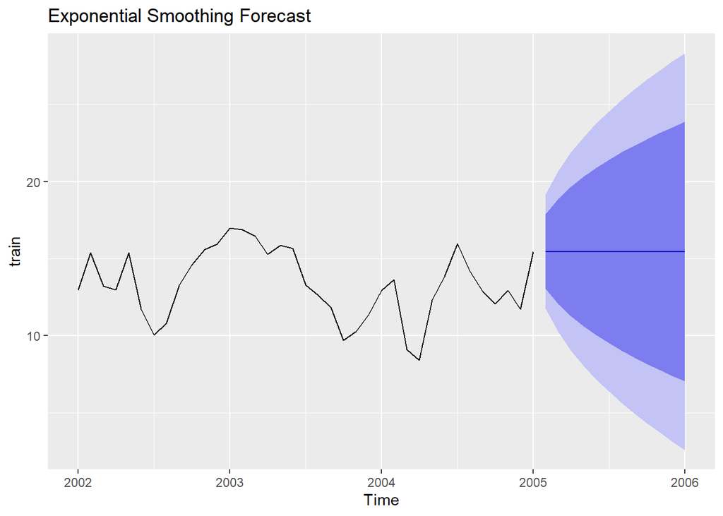

```r
autoplot(exp_smooth_forecast) + ggtitle("Exponential Smoothing Forecast")
```

```r
# Display results for all models
print(naive_forecast)
```

```
##          Point Forecast     Lo 80    Hi 80     Lo 95    Hi 95
## Feb 2005       15.47126 13.076432 17.86609 11.808686 19.13383
## Mar 2005       15.47126 12.084461 18.85806 10.291598 20.65092
## Apr 2005       15.47126 11.323296 19.61922  9.127496 21.81502
## May 2005       15.47126 10.681603 20.26092  8.146112 22.79641
## Jun 2005       15.47126 10.116261 20.82626  7.281496 23.66102
## Jul 2005       15.47126  9.605152 21.33737  6.499823 24.44270
## Aug 2005       15.47126  9.135140 21.80738  5.781000 25.16152
## Sep 2005       15.47126  8.697662 22.24486  5.111936 25.83058
## Oct 2005       15.47126  8.286775 22.65575  4.483538 26.45898
## Nov 2005       15.47126  7.898148 23.04437  3.889184 27.05334
## Dec 2005       15.47126  7.528513 23.41401  3.323876 27.61864
## Jan 2006       15.47126  7.175331 23.76719  2.783732 28.15879
```

```r
print(mean_forecast)
```

```
##          Point Forecast    Lo 80    Hi 80    Lo 95    Hi 95
## Feb 2005       13.34463 10.36373 16.32553 8.713849 17.97541
## Mar 2005       13.34463 10.36373 16.32553 8.713849 17.97541
## Apr 2005       13.34463 10.36373 16.32553 8.713849 17.97541
## May 2005       13.34463 10.36373 16.32553 8.713849 17.97541
## Jun 2005       13.34463 10.36373 16.32553 8.713849 17.97541
## Jul 2005       13.34463 10.36373 16.32553 8.713849 17.97541
## Aug 2005       13.34463 10.36373 16.32553 8.713849 17.97541
## Sep 2005       13.34463 10.36373 16.32553 8.713849 17.97541
## Oct 2005       13.34463 10.36373 16.32553 8.713849 17.97541
## Nov 2005       13.34463 10.36373 16.32553 8.713849 17.97541
## Dec 2005       13.34463 10.36373 16.32553 8.713849 17.97541
## Jan 2006       13.34463 10.36373 16.32553 8.713849 17.97541
```

```r
print(exp_smooth_forecast)
```

```
##          Point Forecast     Lo 80    Hi 80     Lo 95    Hi 95
## Feb 2005       15.47088 13.042078 17.89969 11.756345 19.18542
## Mar 2005       15.47088 12.036205 18.90556 10.217995 20.72377
## Apr 2005       15.47088 11.264349 19.67742  9.037543 21.90423
## May 2005       15.47088 10.613636 20.32813  8.042364 22.89941
## Jun 2005       15.47088 10.040342 20.90143  7.165587 23.77618
## Jul 2005       15.47088  9.522044 21.41973  6.372917 24.56885
## Aug 2005       15.47088  9.045417 21.89635  5.643980 25.29779
## Sep 2005       15.47088  8.601783 22.33999  4.965501 25.97627
## Oct 2005       15.47088  8.185113 22.75666  4.328258 26.61351
## Nov 2005       15.47088  7.791015 23.15075  3.725538 27.21623
## Dec 2005       15.47088  7.416177 23.52559  3.152272 27.78950
## Jan 2006       15.47088  7.058023 23.88375  2.604523 28.33725
```

8. Show model rank with accuracy measures

```r
library(forecast)
naive = accuracy(naive_model, test)
meanf = accuracy(mean_forecast, test)
exp_smooth = accuracy(exp_smooth_model, test)

# Extract MAPE value
naive_mape <- naive["Test set", "MAPE"]
cat("Mean Absolute Percentage Error (MAPE):", naive_mape, "%\n")
```

```
## Mean Absolute Percentage Error (MAPE): 6.759603 %
```

```r
meanf_mape <- meanf["Test set", "MAPE"]
cat("Mean Absolute Percentage Error (MAPE):", meanf_mape, "%\n")
```

```
## Mean Absolute Percentage Error (MAPE): 7.915222 %
```

```r
exp_smooth_mape <- exp_smooth["Test set", "MAPE"]
cat("Mean Absolute Percentage Error (MAPE):", exp_smooth_mape, "%\n")
```

```
## Mean Absolute Percentage Error (MAPE): 6.757012 %
```

```r
# Ranked Models Based on MAPE:
# Store each model's MAPE score in a named list
mape_scores <- list(
  Naive = 6.759603,
  Average = 7.915222,
  Exponential_Smoothing = 6.757012
)

# Convert to a data frame and sort by MAPE in ascending order
mape_df <- as.data.frame(mape_scores, col.names = "MAPE")
mape_df <- stack(mape_df)
names(mape_df) <- c("MAPE", "Model")
mape_df <- mape_df[order(mape_df$MAPE), ]

# Print ranked MAPE scores
print(mape_df)
```

[output not shown]

Overall Best Model

The Exponential Smoothing Model is best based on lowest MAPE score.

9. Choose which models and how are you going to use them for Forecasting

Based on the accuracy measures, I will use the Exponential Smoothing Model for forecasting.

10. Provide the forecast for the next 12 months (point and range) and explain why you feel confident with these forecasts

```r
# Apply exponential smoothing (ETS) model
exp_smooth_model <- ets(ts_data)

# Generate forecasts
exp_smooth_forecast <- forecast(exp_smooth_model, h=12)

# Print and plot the forecasts
print(exp_smooth_forecast)
```

```
##          Point Forecast     Lo 80    Hi 80     Lo 95    Hi 95
## May 2005       14.49198 11.993593 16.99037 10.671026 18.31293
## Jun 2005       14.49198 10.958903 18.02506  9.088606 19.89535
## Jul 2005       14.49198 10.164935 18.81903  7.874335 21.10962
## Aug 2005       14.49198  9.495580 19.48838  6.850646 22.13331
## Sep 2005       14.49198  8.905863 20.07810  5.948751 23.03521
## Oct 2005       14.49198  8.372716 20.61124  5.133373 23.85059
## Nov 2005       14.49198  7.882435 21.10153  4.383553 24.60041
## Dec 2005       14.49198  7.426092 21.55787  3.685637 25.29832
## Jan 2006       14.49198  6.997484 21.98648  3.030138 25.95382
## Feb 2006       14.49198  6.592097 22.39186  2.410151 26.57381
## Mar 2006       14.49198  6.206520 22.77744  1.820462 27.16350
## Apr 2006       14.49198  5.838106 23.14585  1.257021 27.72694
```

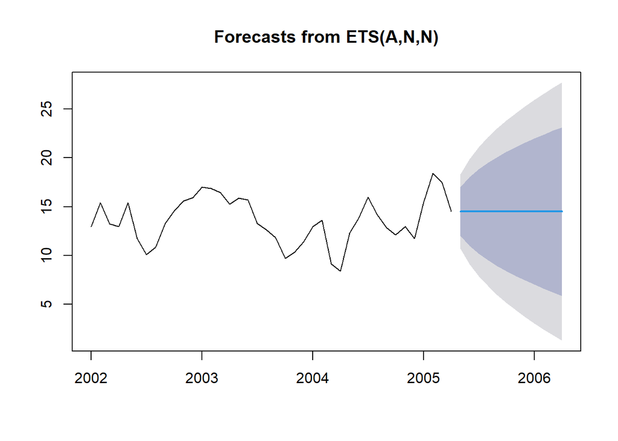

```r
plot(exp_smooth_forecast)
```

```r
# Exponential smoothing is a widely used method in forecasting due to its strong track record across various domains. Its ability to provide both point forecasts and confidence intervals offers a complete picture for decision-making.
```